# Biden’s Approval Margins

2021-09-30

# Biden’s Approval Margins

As we saw in class, fivethirtyeight.com has detailed data on [all polls that track the president’s approval](https://projects.fivethirtyeight.com/biden-approval-ratings)

```r
# Import approval polls data directly off fivethirtyeight website
approval_polllist <- read_csv('https://projects.fivethirtyeight.com/biden-approval-data/approval_polllist.csv')

glimpse(approval_polllist)
```

```
## Rows: 1,945
## Columns: 22
## $ president           <chr> "Joseph R. Biden Jr.", "Joseph R. Biden Jr.", "Jos~
## $ subgroup            <chr> "All polls", "All polls", "All polls", "All polls"~
## $ modeldate           <chr> "10/20/2021", "10/20/2021", "10/20/2021", "10/20/2~
## $ startdate           <chr> "1/19/2021", "1/19/2021", "1/20/2021", "1/20/2021"~
## $ enddate             <chr> "1/21/2021", "1/21/2021", "1/21/2021", "1/22/2021"~
## $ pollster            <chr> "Morning Consult", "Rasmussen Reports/Pulse Opinio~
## $ grade               <chr> "B", "B", "B", "B", "B-", "B+", "B", "B-", "B", "B~
## $ samplesize          <dbl> 15000, 1500, 1993, 15000, 1115, 1516, 15000, 1200,~
## $ population          <chr> "a", "lv", "rv", "a", "a", "a", "a", "rv", "lv", "~
## $ weight              <dbl> 0.2594, 0.3382, 0.0930, 0.2333, 1.1014, 1.2454, 0.~
## $ influence           <dbl> 0, 0, 0, 0, 0, 0, 0, 0, 0, 0, 0, 0, 0, 0, 0, 0, 0,~
## $ approve             <dbl> 50, 48, 56, 51, 55, 45, 52, 58, 48, 63, 55, 53, 48~
## $ disapprove          <dbl> 28, 45, 31, 28, 32, 28, 29, 32, 47, 37, 33, 29, 47~
## $ adjusted_approve    <dbl> 48.5, 50.4, 54.5, 49.5, 53.8, 46.4, 50.5, 56.9, 50~
## $ adjusted_disapprove <dbl> 31.2, 38.7, 34.2, 31.2, 33.0, 28.5, 32.2, 33.1, 40~
## $ multiversions       <chr> NA, NA, NA, NA, NA, NA, NA, NA, NA, NA, NA, NA, NA~
## $ tracking            <lgl> TRUE, TRUE, NA, TRUE, NA, NA, TRUE, NA, TRUE, NA, ~
## $ url                 <chr> "https://morningconsult.com/form/global-leader-app~
## $ poll_id             <dbl> 74272, 74247, 74246, 74273, 74248, 74327, 74274, 7~
## $ question_id         <dbl> 139491, 139395, 139394, 139492, 139404, 139570, 13~
## $ createddate         <chr> "1/28/2021", "1/22/2021", "1/22/2021", "1/28/2021"~
## $ timestamp           <chr> "16:59:11 20 Oct 2021", "16:59:11 20 Oct 2021", "1~
```

```r
# Convert dates from string to date-time
approval_polllist %>%
  select(modeldate, startdate, enddate, createddate, timestamp)%>%
  mutate(poll_date = mdy(createddate), modeldate_as_date = mdy(modeldate), start = mdy(startdate), end = mdy(enddate))
```

```
## # A tibble: 1,945 x 9
##    modeldate  startdate enddate   createddate timestamp poll_date  modeldate_as_da~
##    <chr>      <chr>     <chr>     <chr>       <chr>     <date>     <date>
##  1 10/20/2021 1/19/2021 1/21/2021 1/28/2021   16:59:11~ 2021-01-28 2021-10-20
##  2 10/20/2021 1/19/2021 1/21/2021 1/22/2021   16:59:11~ 2021-01-22 2021-10-20
##  3 10/20/2021 1/20/2021 1/21/2021 1/22/2021   16:59:11~ 2021-01-22 2021-10-20
##  4 10/20/2021 1/20/2021 1/22/2021 1/28/2021   16:59:11~ 2021-01-28 2021-10-20
##  5 10/20/2021 1/20/2021 1/21/2021 1/22/2021   16:59:11~ 2021-01-22 2021-10-20
##  6 10/20/2021 1/20/2021 1/21/2021 2/2/2021    16:59:11~ 2021-02-02 2021-10-20
##  7 10/20/2021 1/21/2021 1/23/2021 1/28/2021   16:59:11~ 2021-01-28 2021-10-20
##  8 10/20/2021 1/21/2021 1/23/2021 1/28/2021   16:59:11~ 2021-01-28 2021-10-20
##  9 10/20/2021 1/20/2021 1/24/2021 1/25/2021   16:59:11~ 2021-01-25 2021-10-20
## 10 10/20/2021 1/21/2021 1/22/2021 1/25/2021   16:59:11~ 2021-01-25 2021-10-20
## # ... with 1,935 more rows, and 2 more variables: start <date>, end <date>
```

```r
#Cannot convert timestamp directly into date-time because of formatting, split into two vectors, reverse order, re-concatenate, convert to date-time
s1 <- stringr::str_split_fixed(approval_polllist$timestamp, " ", n=2)[,1]
s2 <- stringr::str_split_fixed(approval_polllist$timestamp, " ",n=2)[,2]
times <- dmy_hms(paste(s2, s1, sep = "T"))

glimpse(times)
```

```
##  POSIXct[1:1945], format: "2021-10-20 16:59:11" "2021-10-20 16:59:11" "2021-10-20 16:59:11" ...
```

```r
approval_polllist %>%
  add_column(times)
```

```
## # A tibble: 1,945 x 23
##    president   subgroup modeldate startdate enddate pollster    grade samplesize
##    <chr>       <chr>    <chr>     <chr>     <chr>   <chr>       <chr>      <dbl>
##  1 Joseph R. ~ All pol~ 10/20/20~ 1/19/2021 1/21/2~ Morning Co~ B          15000
##  2 Joseph R. ~ All pol~ 10/20/20~ 1/19/2021 1/21/2~ Rasmussen ~ B           1500
##  3 Joseph R. ~ All pol~ 10/20/20~ 1/20/2021 1/21/2~ Morning Co~ B           1993
##  4 Joseph R. ~ All pol~ 10/20/20~ 1/20/2021 1/22/2~ Morning Co~ B          15000
##  5 Joseph R. ~ All pol~ 10/20/20~ 1/20/2021 1/21/2~ Ipsos       B-          1115
##  6 Joseph R. ~ All pol~ 10/20/20~ 1/20/2021 1/21/2~ YouGov      B+          1516
##  7 Joseph R. ~ All pol~ 10/20/20~ 1/21/2021 1/23/2~ Morning Co~ B          15000
##  8 Joseph R. ~ All pol~ 10/20/20~ 1/21/2021 1/23/2~ RMG Resear~ B-          1200
##  9 Joseph R. ~ All pol~ 10/20/20~ 1/20/2021 1/24/2~ Rasmussen ~ B           1500
## 10 Joseph R. ~ All pol~ 10/20/20~ 1/21/2021 1/22/2~ HarrisX     B+           941
## # ... with 1,935 more rows, and 15 more variables: population <chr>,
## #   weight <dbl>, influence <dbl>, approve <dbl>, disapprove <dbl>,
## #   adjusted_approve <dbl>, adjusted_disapprove <dbl>, multiversions <chr>,
## #   tracking <lgl>, url <chr>, poll_id <dbl>, question_id <dbl>,
## #   createddate <chr>, timestamp <chr>, times <dttm>
```

## Create a plot

What I would like you to do is to calculate the average net approval rate (approve- disapprove) for each week since he got into office. I want you plot the net approval, along with its 95% confidence interval. There are various dates given for each poll, please use `enddate`, i.e., the date the poll ended.

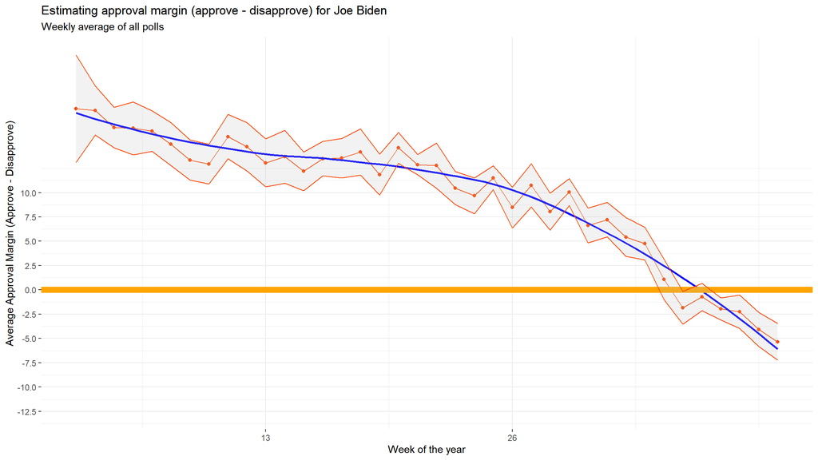

```r
# Create plot here
approval_polllist <- approval_polllist %>%
  select(approve, disapprove, enddate) %>%
  mutate(net_approval = approve - disapprove, end_date = mdy(enddate), week = week(end_date))

newap_list <- approval_polllist %>%
  group_by(week)%>%
  summarize(avg_netapp=mean(net_approval),
              count=n(),
              sdev=sd(net_approval),
              SErr=sdev/sqrt(count),
              t_crit = qt(0.975, count-1),
              CI_low = avg_netapp - t_crit*SErr,
              CI_high= avg_netapp + t_crit*SErr)

  ggplot(newap_list, aes(x = week, y = avg_netapp))+
  geom_point(colour = "orangered1")+
  geom_line(colour = "orangered1")+
  geom_smooth(colour = "blue", se = FALSE) +
  geom_hline(yintercept = 0, color = "orange", size = 3)+
  scale_y_continuous(breaks = seq(-15, 10, by = 2.5))+
  scale_x_continuous(breaks = c(13,26), limits = c(3, 40))+
  geom_ribbon(aes(ymin=CI_low, ymax=CI_high) ,fill="grey", alpha=0.2, colour = "orangered1", outline.type = "both")+
  labs(title = "Estimating approval margin (approve - disapprove) for Joe Biden", subtitle = "Weekly average of all polls", x = "Week of the year", y = "Average Approval Margin (Approve - Disapprove)")+
  theme_bw() +
    theme(panel.border = element_blank())
```

## Compare Confidence Intervals

Compare the confidence intervals for `week 3` and `week 25`. Can you explain what’s going on? One paragraph would be enough.

The confidence interval in week 3 was much wider than during any other time of 2021, but especially week 25. Trump supporters had stormed the capital on 6 January. The aftermath of this fallout probably led to the significantly increased width of the confidence interval. Another explanation could be that Biden assumed the presidency around that time and respondents of the survey could not base their approval on actual political action Biden had undertaken at the time. Week 25 was at the end of June and the 4th of July was coming up. The national holiday in the United States was likely the force behind the smaller confidence interval. Besides, Biden had ordered a military strike on Iran-backed militia in Iraq and Syria, which might be another reason for the decreased width of the confidence interval as military action against a common enemy unites a nation.